# Clase 4 de Mayo

April 24, 2018

## Análisis exploratorio y curación de datos

- Mariano Dominguez @ IATE-OAC-UNC & CONICET
- Edgardo Hames @ Bitlogic
- Gabriel Miretti @ Bitlogic

[figure not shown]

Diplodatos @ FaMAF

## Paradigmas cientificos clasicos:

Siglos atras la ciencia era **empirica**, describiendo los procesos naturales.

[figure not shown]

Galileo observando con un telescopio

luego se desarrollaron modelos **teoricos** matematicos, generalizaciones

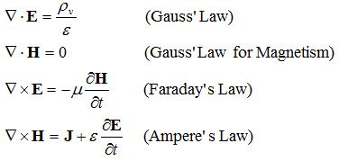

## Astronomia (u otra ciencia) Computacional

En las ultimas decadas se han simulando fenomenos complejos.

[figure not shown]

Simulacion cosmologica LCDM

## El cuarto paradigma en ciencia:

Hoy en dia la exploracion de datos (eScience) unifica la teoria, los experimentos y las simulaciones.

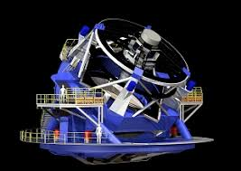

LSST telescopio y camara

http://www.astro.caltech.edu/~george/aybi199/4th_paradigm_book_complete_lr.pdf

## Por que (no) R? es FLOSS!

Introduccion al lenguaje estadistico R http://r-project.org y CRAN http://cran.r-project.org/ : R consiste en una colleccion de software con una importante variedad de paquetes para analisis de datos, matematica aplicada, estadistica , graficos y diferentes utilidades. Los paquetes extras en CRAN son suministrados por individuos o comunidades de expertos en biologia, economia, geologia y otros campos (ver https://www.jstatsoft.org/index ).

Existe una linda IDE: RStudio https://www.rstudio.com/ y una muy buena biblioteca para graficos ggplot2 (now ggviz). Tambien existen diversas galeria de graficos en R y recientemente se ha establecido el consorcio R: https://www.r-consortium.org/ (Microsoft compro Revolution, ver tambien h2o).

Esta es una presentacion en R Markdown. Markdown es un formato de sintaxis simple para crear documentos HTML, PDF y MS Word. Por mas detalles de comom utilizar R Markdown ver http://rmarkdown.rstudio.com.

Cuando se clickea el boton **Knit**, un documento es generado que incluye el contenido asi como los outputs de de los chuncks de codigos R embebidos en el documento ver https://legacy.gitbook.com/book/bids/the-practice-of-reproducible-research/details y https://arxiv.org/abs/1605.04339.

**Shiny** is un paquete de R que permite constriur apps interactivos directamente en R Markdown, webpages o cosntruir dashboards. Ademas se pueden extender los Shiny apss con temas CSS, htmlwidgets y herramientas de JavaScript https://shiny.rstudio.com/galley .

## Estadistica con R

Una nocion basica es la de una muestra aleatoria.

E R es posible simular facilmente esta situacion con la funcion **sample**. Si por ejemplo quiero elegir cinco numero aleatorios entre 1 y 40, escribo:

```r
sample(1:40,5)
```

```
## [1] 36 32 34 24 26
```

Muestrear con reeemplazo es adecuado para modelar monedas o dados. Por ejemplo para simular arrojar diez monedas podemos escribir:

```r
sample(c("H","T"), 10, replace=T)
```

```
##  [1] "H" "H" "T" "T" "T" "H" "T" "H" "H" "H"
```

Tambien se puede simular datos con diferentes probabilidades de cada resultado, (por ejemplo tener una tasa de exitos del 90%) utilizando el argumento prob in sample:

```r
sample(c("succ", "fail"), 10, replace=T, prob=c(0.9, 0.1))
```

```
##  [1] "succ" "succ" "succ" "succ" "succ" "succ" "succ" "succ" "succ" "succ"
```

## Distribuciones discretas en R:

cuando las variables solo pueden tomar solamente valores finitos, es preferible dibujar un digrama de alfileres (pin), aqui podemos observar la distribucion binomial con n=50 y p=0.33.

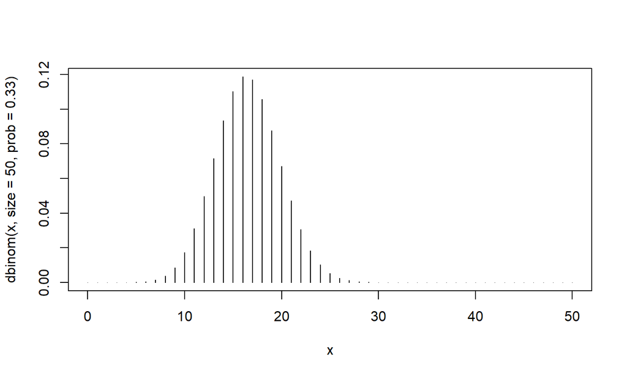

```r
x <- 0:50
plot(x,dbinom(x,size=50,prob=.33),type="h")
```

## Numeros Aleatorios:

En general suena contradictorio generar numeros aleatorios en una computadora dado que se supone que sus resultados son predecibles y reproducibles. Lo que en realidad es posible es generar secuencias de numeros pseudo aleatorios, que para todos los efectos practicos se comportan como si fueran aleatorios. Ver sobre LCGs, http://www.aaronschlegel.com/series/random-number-generation/

En estadistica se utilizan para crear conjuntos de datos simulados para estudiar los efectos de los algoritmos. El uso de funciones que generan numeros aleatorios es simple, por ejemplo numeros que siguen una distribucion normal:

```r
n=100
x <- rnorm (n, mean=0, sd=1)
mean(x)
```

```
## [1] -0.1207571
```

```r
sd(x)
```

```
## [1] 0.96654
```

```r
quantile(x)
```

```
##         0%        25%        50%        75%       100%
## -2.2782917 -0.6380525 -0.0938529  0.4231234  3.1343328
```

### Distribution uniforme

El generador basico en R es runif, cuya entrada es el numero de valores a ser generados.

```r
runif(10, min=2, max=5)
```

```
##  [1] 4.191560 3.880137 2.033144 4.715935 4.637297 2.165917 2.467976
##  [8] 4.448462 3.675002 4.252842
```

Veamos como funciona:

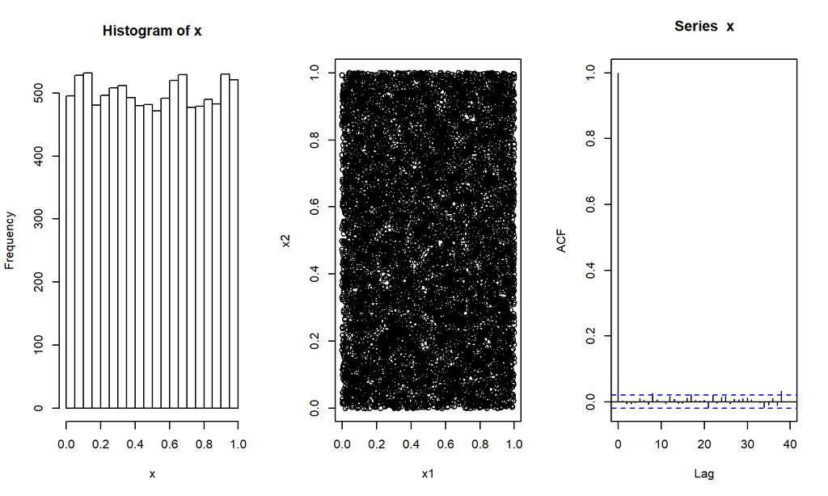

```r
Nsim=10^4
x=runif(Nsim)
x1=x[-Nsim]
x2=x[-1]
par(mfrow=c(1,3))
hist(x)
plot(x1,x2)
acf(x)
```

### Guardando las semillas.

runif no implica aleatoridad per se. runif(Nsim) es calcular una secuencia deterministica basada en un numero aleatorio inicial (semilla).

```r
set.seed(1)
runif(5)
```

```
## [1] 0.2655087 0.3721239 0.5728534 0.9082078 0.2016819
```

```r
set.seed(1)
runif(5)
```

```
## [1] 0.2655087 0.3721239 0.5728534 0.9082078 0.2016819
```

```r
set.seed(2)
runif(5)
```

```
## [1] 0.1848823 0.7023740 0.5733263 0.1680519 0.9438393
```

```r
MC1seed <- .Random.seed # save the generator state
.Random.seed <- MC1seed # restore seed
```

### La transformacion Inversa del CDF:

Existe una transformacion simple, que nos permite transformar cualquier variable aleatoria en una uniforme y mas importante viceversa.

Por ejemplo si \(x\) esta dada por una densidad de probabilidad \(f\) y una CDF \(F\) , entonces vale la relacion: \(F(x)=\int_{-\infty}^{x} f(t) \delta t\) y si elegmimos \(U = F (X)\), con \(U\) una variable aleatoria distribuida uniformemente.

Ejemplo: Si \(X \propto exp\), entonces \(F (x) = 1-e^{-x}\) . Resolviendo para \(x\) en \(u = 1-e^{-x}\) nos da \(x = -log(1 - u)\). Por lo tanto si \(u\) es uniforme, entonces \(X \propto exp\)

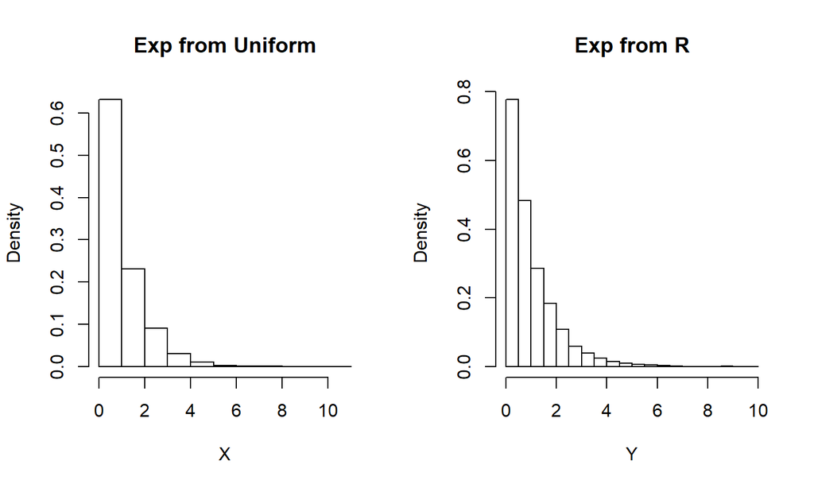

```r
Nsim=10^4
#number of random variables
U=runif(Nsim)
X=-log(U)
#transforms of uniforms
Y=rexp(Nsim)
#exponentials from R
par(mfrow=c(1,2))
#plots
hist(X,freq=F,main="Exp from Uniform")
hist(Y,freq=F,main="Exp from R")
```

## Submuestras

Los comandos subset(), which() and ifelse() son probablemente los mas utilizados en R. Una manera de filtrar elementos de un vector es utilizar la funcion subset().

```r
# create a vector
x <- c(5,4:8,12)
x
```

```
## [1]  5  4  5  6  7  8 12
```

```r
y <- subset(x, x < 6)
y
```

```
## [1] 5 4 5
```

## Utilizando which()

identifica la posicion del vector donde se cumple (is TRUE) la condicion: Vea el siguiente ejemplo de como utilizarla:

```r
# create a vector
z <- c(6:10, 12, -3)
z
```

```
## [1]  6  7  8  9 10 12 -3
```

```r
which(z > 8)
```

```
## [1] 4 5 6
```

## Utilizando ifelse

el comnado ifelse tiene dos opciones para ejecutar. Si la condicion es TRUE se ejecuta la primera, si la condicion es FALSE se ejecuta la segunda. La sintaxis es ifelse(condition, opcion1, opcion2). Un ejemplo a continuacion.

```r
# create a vector
x <- c(-2, 5:10, 15)
x
```

```
## [1] -2  5  6  7  8  9 10 15
```

```r
# if values are < 7 will code those 1, else will become 0
ifelse(x < 7, 1, 0)
```

```
## [1] 1 1 1 0 0 0 0 0
```

```r
# also you can do this
ifelse(x < 7, 1, x)
```

```
## [1]  1  1  1  7  8  9 10 15
```

## Code the Matrix 1:

Creamos una matriz x con numeros provenientes de una funcion normal. y llamamos a sus elementos con x[fila,columna].

```r
# matrix with 12 random numbers in 4 rows
x <- matrix(rnorm(12), nrow=4)
x
```

```
##            [,1]       [,2]       [,3]
## [1,]  1.2891946 -1.9527802 -0.0692199
## [2,]  0.5955489 -0.3774369  0.1197222
## [3,]  1.1870120  0.4915441  0.9573790
## [4,] -0.1418306  0.1169809 -0.3900849
```

```r
# find the number in 3rd row and 2nd column
x[3,2]
```

```
## [1] 0.4915441
```

## Code the Matrix 2:

tambien es posible referirse a una columna o fila u obtener las dimensiones.

```r
# show second columns
x[,2]
```

```
## [1] -1.9527802 -0.3774369  0.4915441  0.1169809
```

```r
# show forth row
x[4,]
```

```
## [1] -0.1418306  0.1169809 -0.3900849
```

```r
# find number or columns and rows in matrix
dim(x)
```

```
## [1] 4 3
```

### Utilizando lazos en R:

Cada vez que alguna operacion debe ser repetida un lazo resulta util. De acuerdo el manual de R, entre los comandos basicos de control de flujo, las construcciones para lazos son: fort, while y repeat, con las clausulas adicionales break y next.

```r
?Control
```

```
## starting httpd help server ... done
```

Un ejemplo de un lazo simple:

```r
u1 <- rnorm(30) # create a vector filled with random normal values
print("This loop calculates the square of the first 10 elements of
vector u1")
```

```
## [1] "This loop calculates the square of the first 10 elements of\nvector u1"
```

```r
usq<-0
for(i in 1:10)
{
usq[i]<-u1[i]*u1[i] # i-th element of u1 squared into i-th position
print(usq[i])
}
```

```
## [1] 0.1361074
## [1] 0.01092893
## [1] 0.1821844
## [1] 0.443898
## [1] 0.3556551
## [1] 0.1570116
## [1] 0.3365243
## [1] 2.490043
## [1] 0.01931025
## [1] 1.317743
```

```r
print(i)
```

```
## [1] 10
```

Por lo que el bloque del lazo es contenido por {}.

### Lazos anidados

Supongamos que queremos manipular una matriz poniendo sus elementos con valores especificos:

```r
# nested for: multiplication table
mymat = matrix(nrow=30, ncol=30) # create a 30 x 30 matrix
for(i in 1:dim(mymat)[1]){
   # for each row
   for(j in 1:dim(mymat)[2]){
      # for each column
      # assign values based on position: product of two indexes
      mymat[i,j] = i*j
   }
}
mymat[1:10,1:10] # show just the upper left 10x10 chunk
```

```
##       [,1] [,2] [,3] [,4] [,5] [,6] [,7] [,8] [,9] [,10]
##  [1,]    1    2    3    4    5    6    7    8    9    10
##  [2,]    2    4    6    8   10   12   14   16   18    20
##  [3,]    3    6    9   12   15   18   21   24   27    30
##  [4,]    4    8   12   16   20   24   28   32   36    40
##  [5,]    5   10   15   20   25   30   35   40   45    50
##  [6,]    6   12   18   24   30   36   42   48   54    60
##  [7,]    7   14   21   28   35   42   49   56   63    70
##  [8,]    8   16   24   32   40   48   56   64   72    80
##  [9,]    9   18   27   36   45   54   63   72   81    90
## [10,]   10   20   30   40   50   60   70   80   90   100
```

### Vectorizacion 1:

es la operacion de convertir repetidas operaciones en numeros (escalares) en operaciones en vectores o matrices. Muchos lazos pueden hacerse implicitos con vectorizacion.

el ejemplo mas elemental es la adicion de dos vectores v1 y v2 en un vector v3, lo que puede hacerse elemento por elemento con un lazo:

```r
n=100
v1 <- rnorm(n)
v2 <- rnorm(n)
v3 <- 0
#
for (i in 1:n)
{
v3[i] <-v1[i] + v2[i]
}
```

### Vectorizacion 2:

o utilizando la forma vectorizada:

```r
v3 = v1 + v2
```

lo que permite utilizar eficientemente rutinas muy eficientes de algebra lineal (BLAS)

Comparemos el tiempo de ejecucion entre ambas soluciones:

```r
m=10; n=10;
mymat<-replicate(m, rnorm(n)) # create matrix of normal random numbers
mydframe=data.frame(mymat) # transform into data frame
# measure loop execution
system.time(
for (i in 1:m) {
for (j in 1:n) {
mydframe[i,j]<-mydframe[i,j] + 10*sin(0.75*pi)
}
}
)
```

```
##    user  system elapsed
##    0.02    0.00    0.01
```

Ejercicio: Mida el tiempo en una version vectorizada.

### La familia de instrucciones apply.

Esta compuesta de funciones intrinsecamente vectorizada y esta compuesta de funciones ([s,l,m,r, t,v]apply) para manipular datos en forma de matrices en una forma repetitiva, evitando el uso explicito de lazos. Las primeras tres son las mas utilizadas:

1. apply permite aplicar una funcion a filas (primer indice) o columnas (segundo indice) de una matriz.
2. lapply permite aplicar una dada funcion a cada elemento de una lista.
3. sapply igual que la anterior, pero se obtiene un vector en lugar de una lista.

```r
#### elementary example of apply function
# define matrix mymat by replicating the sequence 1:5 for 4 times and transforming into a matrix
mymat<-matrix(rep(seq(5), 4), ncol = 5)
# mymat sum on rows
apply(mymat, 1, sum)
```

```
## [1] 15 15 15 15
```

```r
# mymat sum on columns
apply(mymat, 2, sum)
```

```
## [1] 10 11 12 13 14
```

```r
# produce a summary column wise (for each column)
apply(mymat, 2, function(x, y) summary(mymat))
```

```
##       [,1]             [,2]             [,3]             [,4]
##  [1,] "Min.   :1.00  " "Min.   :1.00  " "Min.   :1.00  " "Min.   :1.00  "
##  [2,] "1st Qu.:1.75  " "1st Qu.:1.75  " "1st Qu.:1.75  " "1st Qu.:1.75  "
##  [3,] "Median :2.50  " "Median :2.50  " "Median :2.50  " "Median :2.50  "
##  [4,] "Mean   :2.50  " "Mean   :2.50  " "Mean   :2.50  " "Mean   :2.50  "
##  [5,] "3rd Qu.:3.25  " "3rd Qu.:3.25  " "3rd Qu.:3.25  " "3rd Qu.:3.25  "
##  [6,] "Max.   :4.00  " "Max.   :4.00  " "Max.   :4.00  " "Max.   :4.00  "
##  [7,] "Min.   :1.00  " "Min.   :1.00  " "Min.   :1.00  " "Min.   :1.00  "
##  [8,] "1st Qu.:1.75  " "1st Qu.:1.75  " "1st Qu.:1.75  " "1st Qu.:1.75  "
##  [9,] "Median :2.50  " "Median :2.50  " "Median :2.50  " "Median :2.50  "
## [10,] "Mean   :2.75  " "Mean   :2.75  " "Mean   :2.75  " "Mean   :2.75  "
## [11,] "3rd Qu.:3.50  " "3rd Qu.:3.50  " "3rd Qu.:3.50  " "3rd Qu.:3.50  "
## [12,] "Max.   :5.00  " "Max.   :5.00  " "Max.   :5.00  " "Max.   :5.00  "
## [13,] "Min.   :1.00  " "Min.   :1.00  " "Min.   :1.00  " "Min.   :1.00  "
## [14,] "1st Qu.:1.75  " "1st Qu.:1.75  " "1st Qu.:1.75  " "1st Qu.:1.75  "
```

[output cut: 47 more lines]

## Importando y exportando datos.

Los datos en R pueden guardarse como archivos .Rdata con la funcion save. Que luego pueden leerse en R con load.

```r
a <- 1:10
save(a, file = "Data.Rdata")
rm(a)
load("Data.Rdata")
print(a)
```

```
##  [1]  1  2  3  4  5  6  7  8  9 10
```

## Presentando los Data Frames:

El siguiente ejemplo crea un dataframe a y lo guarda como un archivo CSV con write.cvs. Luego el dataframe is cargado desde el archivo a una variable b con read.cvs.

```r
var1 <- 1:5
var2 <- (1:5) / 10
var3 <- c("Diplo", "Datos", "en", "FaMAF", "@UNC")
a <- data.frame(var1, var2, var3)
names(a) <- c("VariableInt", "VariableReal", "VariableChar")
write.csv(a, "Data.csv", row.names = FALSE)
 #rm(a)
b <- read.csv("Data.csv")
print(b)
```

```
##   VariableInt VariableReal VariableChar
## 1           1          0.1        Diplo
## 2           2          0.2        Datos
## 3           3          0.3           en
## 4           4          0.4        FaMAF
## 5           5          0.5         @UNC
```

## Creando un Data Frame

Un data frame es similar a una matriz, pero puede contener elementos numericos o texto. La funcion que se utiliza para crear data frames es dataframe() por ej:

```r
# create a data frame
hospital <- c("Cordoba", "Buenos Aires")
pacientes <- c(150, 350)
df <- data.frame(hospital, pacientes)
df
```

```
##       hospital pacientes
## 1      Cordoba       150
## 2 Buenos Aires       350
```

```r
# structure
str(df)
```

```
## 'data.frame':    2 obs. of  2 variables:
##  $ hospital : Factor w/ 2 levels "Buenos Aires",..: 2 1
##  $ pacientes: num  150 350
```

## Read Write Table

```r
write.table(df,file="data.dat")
```

```r
misdatos <- read.table("data.dat")
misdatos$hospital
```

```
## [1] Cordoba      Buenos Aires
## Levels: Buenos Aires Cordoba
```

```r
misdatos["hospital"]
```

```
##       hospital
## 1      Cordoba
## 2 Buenos Aires
```

crea un marco de datos denominado misdatos

Existen varias opciones con valores por defecto (aquellos usados por R si son omitidos por el usuario). Para solicitar ayuda utilizar ?

```r
?read.table
```

Para mas ejemplos de uso de R puede consultarse https://www.computerworld.com/article/2497464/business-intelligence/top-r-language-resources-to-improve-your-data-skills.html en particular es muy recomendable el paquete http://swirlstats.com/

Para extender el manejo de R ver http://adv-r.had.co.nz/ y como construir paquetes http://r-pkgs.had.co.nz/ y por supuesto <www.r-graph-gallery.com>

## coffe & mate breack?

## Algunos Datasets intrinsecos:

iris dataset

```r
str(iris)
```

```
## 'data.frame':    150 obs. of  5 variables:
##  $ Sepal.Length: num  5.1 4.9 4.7 4.6 5 5.4 4.6 5 4.4 4.9 ...
##  $ Sepal.Width : num  3.5 3 3.2 3.1 3.6 3.9 3.4 3.4 2.9 3.1 ...
##  $ Petal.Length: num  1.4 1.4 1.3 1.5 1.4 1.7 1.4 1.5 1.4 1.5 ...
##  $ Petal.Width : num  0.2 0.2 0.2 0.2 0.2 0.4 0.3 0.2 0.2 0.1 ...
##  $ Species     : Factor w/ 3 levels "setosa","versicolor",..: 1 1 1 1 1 1 1 1 1 1 ...
```

bodyfat dataset, brief excursion to install.packages("") details:

```r
library(mboost)
data("bodyfat", package="TH.data")
str(bodyfat)
```

```
## 'data.frame':    71 obs. of  10 variables:
##  $ age         : num  57 65 59 58 60 61 56 60 58 62 ...
##  $ DEXfat      : num  41.7 43.3 35.4 22.8 36.4 ...
##  $ waistcirc   : num  100 99.5 96 72 89.5 83.5 81 89 80 79 ...
##  $ hipcirc     : num  112 116.5 108.5 96.5 100.5 ...
##  $ elbowbreadth: num  7.1 6.5 6.2 6.1 7.1 6.5 6.9 6.2 6.4 7 ...
##  $ kneebreadth : num  9.4 8.9 8.9 9.2 10 8.8 8.9 8.5 8.8 8.8 ...
##  $ anthro3a    : num  4.42 4.63 4.12 4.03 4.24 3.55 4.14 4.04 3.91 3.66 ...
##  $ anthro3b    : num  4.95 5.01 4.74 4.48 4.68 4.06 4.52 4.7 4.32 4.21 ...
##  $ anthro3c    : num  4.5 4.48 4.6 3.91 4.15 3.64 4.31 4.47 3.47 3.6 ...
##  $ anthro4     : num  6.13 6.37 5.82 5.66 5.91 5.14 5.69 5.7 5.49 5.25 ...
```

```r
head(bodyfat)
```

```
##    age DEXfat waistcirc hipcirc elbowbreadth kneebreadth anthro3a anthro3b
## 47  57  41.68     100.0   112.0          7.1         9.4     4.42     4.95
## 48  65  43.29      99.5   116.5          6.5         8.9     4.63     5.01
## 49  59  35.41      96.0   108.5          6.2         8.9     4.12     4.74
## 50  58  22.79      72.0    96.5          6.1         9.2     4.03     4.48
## 51  60  36.42      89.5   100.5          7.1        10.0     4.24     4.68
## 52  61  24.13      83.5    97.0          6.5         8.8     3.55     4.06
##    anthro3c anthro4
## 47     4.50    6.13
## 48     4.48    6.37
## 49     4.60    5.82
## 50     3.91    5.66
## 51     4.15    5.91
## 52     3.64    5.14
```

## Exploracion de Datos 1:

- 1-Checkeando las dimensiones

```r
dim(iris)
```

```
## [1] 150   5
```

- 2 nombre de las variable o columnas

```r
names(iris)
```

```
## [1] "Sepal.Length" "Sepal.Width"  "Petal.Length" "Petal.Width"
## [5] "Species"
```

- 3 Structura

```r
str(iris)
```

```
## 'data.frame':    150 obs. of  5 variables:
##  $ Sepal.Length: num  5.1 4.9 4.7 4.6 5 5.4 4.6 5 4.4 4.9 ...
##  $ Sepal.Width : num  3.5 3 3.2 3.1 3.6 3.9 3.4 3.4 2.9 3.1 ...
##  $ Petal.Length: num  1.4 1.4 1.3 1.5 1.4 1.7 1.4 1.5 1.4 1.5 ...
##  $ Petal.Width : num  0.2 0.2 0.2 0.2 0.2 0.4 0.3 0.2 0.2 0.1 ...
##  $ Species     : Factor w/ 3 levels "setosa","versicolor",..: 1 1 1 1 1 1 1 1 1 1 ...
```

## Exploracion de Datos 2:

- 4 Attributos

```r
attributes(iris)
```

```
## $names
## [1] "Sepal.Length" "Sepal.Width"  "Petal.Length" "Petal.Width"
## [5] "Species"
##
## $class
## [1] "data.frame"
##
## $row.names
##   [1]   1   2   3   4   5   6   7   8   9  10  11  12  13  14  15  16  17
##  [18]  18  19  20  21  22  23  24  25  26  27  28  29  30  31  32  33  34
##  [35]  35  36  37  38  39  40  41  42  43  44  45  46  47  48  49  50  51
##  [52]  52  53  54  55  56  57  58  59  60  61  62  63  64  65  66  67  68
##  [69]  69  70  71  72  73  74  75  76  77  78  79  80  81  82  83  84  85
##  [86]  86  87  88  89  90  91  92  93  94  95  96  97  98  99 100 101 102
## [103] 103 104 105 106 107 108 109 110 111 112 113 114 115 116 117 118 119
## [120] 120 121 122 123 124 125 126 127 128 129 130 131 132 133 134 135 136
## [137] 137 138 139 140 141 142 143 144 145 146 147 148 149 150
```

## Exploracion de Datos 3:

- 5 Veamos las primeras 5 filas

```r
iris[1:5,]
```

```
##   Sepal.Length Sepal.Width Petal.Length Petal.Width Species
## 1          5.1         3.5          1.4         0.2  setosa
## 2          4.9         3.0          1.4         0.2  setosa
## 3          4.7         3.2          1.3         0.2  setosa
## 4          4.6         3.1          1.5         0.2  setosa
## 5          5.0         3.6          1.4         0.2  setosa
```

- 6 Veamos los valores de alguna columna

```r
iris[1:10, "Sepal.Length"]
```

```
##  [1] 5.1 4.9 4.7 4.6 5.0 5.4 4.6 5.0 4.4 4.9
```

## Imputacion de valores NA 1:

```r
# Introduce missing values
set.seed(100)
original<-iris
iris[sample(1:nrow(iris), 40), "Sepal.Length"] <- NA
library(mice)
md.pattern(iris)
```

```
##     Sepal.Width Petal.Length Petal.Width Species Sepal.Length
## 110           1            1           1       1            1  0
##  40           1            1           1       1            0  1
##               0            0           0       0           40 40
```

## Imputacion de valores NA 2:

Esto puede visualizarse como

```r
library(VIM)
```

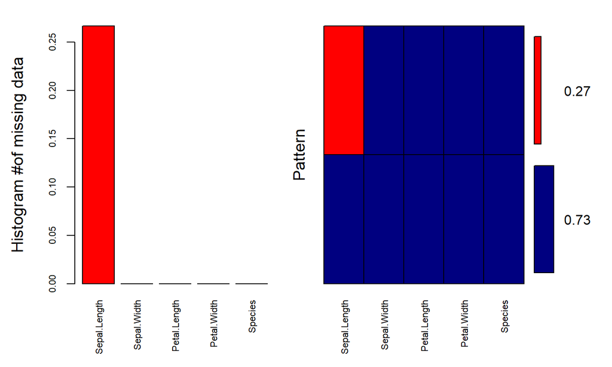

```
##
##  Variables sorted by number of missings:
##      Variable     Count
##  Sepal.Length 0.2666667
##   Sepal.Width 0.0000000
##  Petal.Length 0.0000000
##   Petal.Width 0.0000000
##       Species 0.0000000
```

```r
aggr_plot <- aggr(iris, col=c('navyblue','red'), numbers=TRUE, sortVars=TRUE, labels=names(iris), cex.axis=.7, gap=3, ylab=c("Histogram #of missing data","Pattern"))
```

## Imputacion de valores NA 3:

Para tratar con valores perdidos, el metodo principal es imputar esos valores por ejemplo con la media, mediana, moda o valores cercanos. Otra opcion si se disponen de suficientes datos es ignorar esa medicion (na.action=na.omit)

```r
library(Hmisc)
impute(iris$Sepal.Length, mean)  # replace with mean
```

```
##         1         2         3         4         5         6         7
##  5.100000  4.900000  4.700000  4.600000  5.000000  5.400000  4.600000
##         8         9        10        11        12        13        14
##  5.000000 5.806364*  4.900000  5.400000  4.800000  4.800000  4.300000
##        15        16        17        18        19        20        21
## 5.806364*  5.700000  5.400000  5.100000  5.700000  5.100000 5.806364*
##        22        23        24        25        26        27        28
## 5.806364*  4.600000  5.100000 5.806364*  5.000000  5.000000 5.806364*
##        29        30        31        32        33        34        35
##  5.200000  4.700000  4.800000  5.400000  5.200000 5.806364*  4.900000
##        36        37        38        39        40        41        42
##  5.000000  5.500000  4.900000 5.806364*  5.100000  5.000000 5.806364*
##        43        44        45        46        47        48        49
##  4.400000  5.000000  5.100000  4.800000 5.806364* 5.806364*  5.300000
##        50        51        52        53        54        55        56
##  5.000000  7.000000  6.400000 5.806364*  5.500000 5.806364*  5.700000
##        57        58        59        60        61        62        63
##  6.300000  4.900000 5.806364*  5.200000  5.000000  5.900000  6.000000
##        64        65        66        67        68        69        70
##  6.100000  5.600000  6.700000 5.806364*  5.800000 5.806364* 5.806364*
##        71        72        73        74        75        76        77
## 5.806364* 5.806364*  6.300000  6.100000  6.400000  6.600000  6.800000
##        78        79        80        81        82        83        84
## 5.806364*  6.000000  5.700000 5.806364* 5.806364*  5.800000  6.000000
##        85        86        87        88        89        90        91
##  5.400000  6.000000  6.700000 5.806364*  5.600000  5.500000 5.806364*
##        92        93        94        95        96        97        98
## 5.806364*  5.800000  5.000000  5.600000 5.806364*  5.700000  6.200000
##        99       100       101       102       103       104       105
##  5.100000  5.700000  6.300000  5.800000 5.806364* 5.806364*  6.500000
##       106       107       108       109       110       111       112
##  7.600000  4.900000  7.300000 5.806364*  7.200000 5.806364* 5.806364*
##       113       114       115       116       117       118       119
##  6.800000  5.700000  5.800000  6.400000 5.806364*  7.700000 5.806364*
##       120       121       122       123       124       125       126
##  6.000000  6.900000  5.600000 5.806364*  6.300000  6.700000  7.200000
##       127       128       129       130       131       132       133
## 5.806364*  6.100000  6.400000  7.200000  7.400000  7.900000 5.806364*
##       134       135       136       137       138       139       140
##  6.300000 5.806364*  7.700000  6.300000  6.400000  6.000000  6.900000
##       141       142       143       144       145       146       147
##  6.700000  6.900000 5.806364*  6.800000  6.700000 5.806364*  6.300000
##       148       149       150
##  6.500000 5.806364*  5.900000
```

## Exploracion de variables individuales 1:

- 1 Distribucion de cada variable

```r
iris<-original
summary(iris)
```

```
##   Sepal.Length    Sepal.Width     Petal.Length    Petal.Width
##  Min.   :4.300   Min.   :2.000   Min.   :1.000   Min.   :0.100
##  1st Qu.:5.100   1st Qu.:2.800   1st Qu.:1.600   1st Qu.:0.300
##  Median :5.800   Median :3.000   Median :4.350   Median :1.300
##  Mean   :5.843   Mean   :3.057   Mean   :3.758   Mean   :1.199
##  3rd Qu.:6.400   3rd Qu.:3.300   3rd Qu.:5.100   3rd Qu.:1.800
##  Max.   :7.900   Max.   :4.400   Max.   :6.900   Max.   :2.500
##        Species
##  setosa    :50
##  versicolor:50
##  virginica :50
##
##
##
```

## Exploracion de variables individuales 2:

- 2 Frecuencia

```r
table(iris$Species)
```

```
##
##     setosa versicolor  virginica
##         50         50         50
```

- 3 Pie chart

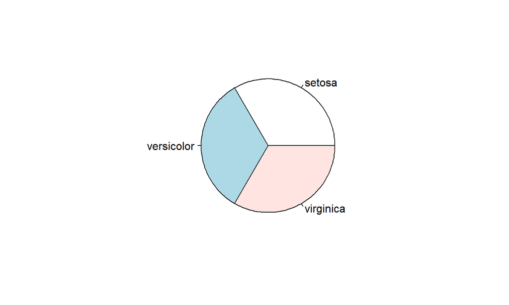

```r
pie(table(iris$Species))
```

## Exploracion de variables individuales 3:

- 4 media y varianza de la Sepal.Length

```r
mean(iris$Sepal.Length)
```

```
## [1] 5.843333
```

```r
var(iris$Sepal.Length)
```

```
## [1] 0.6856935
```

## Exploracion de variables individuales 4:

- 5 Histogramas

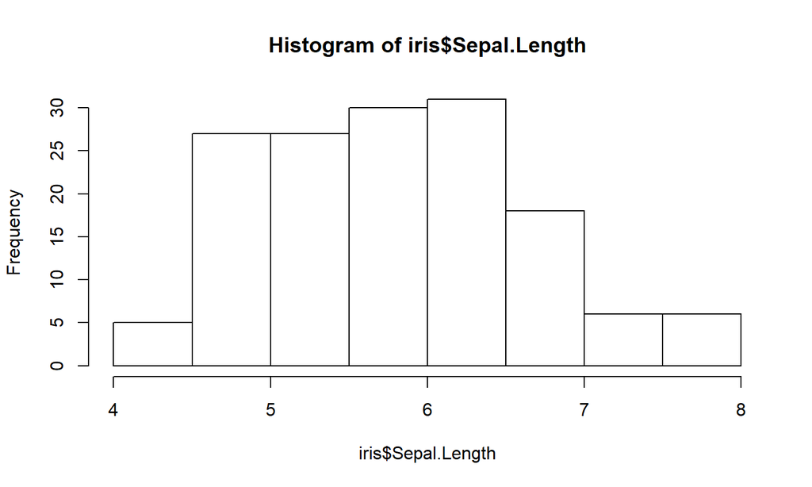

```r
hist(iris$Sepal.Length)
```

## Exploracion de variables individuales 5:

- 6 Densidad

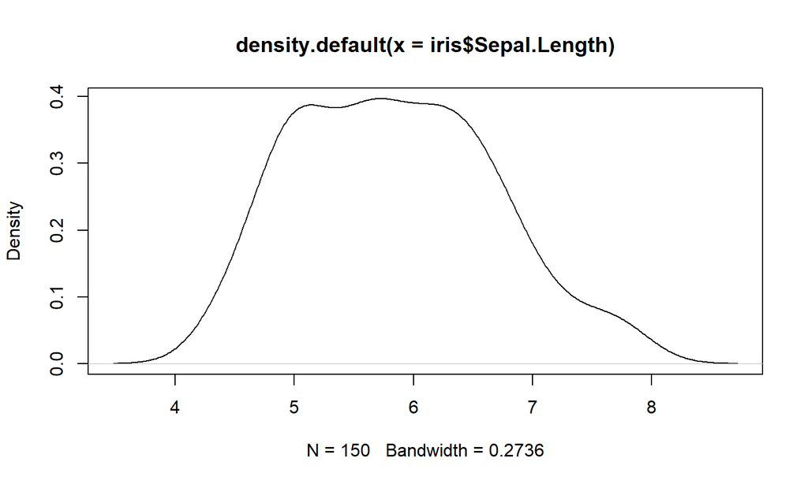

```r
plot(density(iris$Sepal.Length))
```

## Errores como features:

El vocabulario internacional de metrologia (VIM) define una cantidad como **una propiedad de un fenomeno, cuerpo o substancia, donde la propiedad tiene una magnitud que puede ser expresada como un numero y una referencia**.

donde tipicamente el numero es el **valor de una cantidad** obtenida mediante un procedimiento de medicion, y la referencia es la **unidad de medicion**.

Adicionalmente, toda cantidad debe tener asociada alguna indicacion sobre la calidad de la medicion, esto es un atributo cuantificable conocido como **incerteza o error**, que caracteriza que dispersion de valores que pueden ser atribuibles a una dada medicion.

Las incertezas pueden ser directamente medidas o derivadas en el caso de una medicion indirecta (Potencia=Voltaje*corriente) y deben obtenerse por propagacion. Ver las librerias units y errors en CRAN, para un uso adecuado de las mismas como features o cuando se generan nuevos.

## Explorando multiples variables 1:

- 1 covariance of two variables

```r
cov(iris$Sepal.Length, iris$Petal.Length)
```

```
## [1] 1.274315
```

- 2 Correlation of two variables

```r
cor(iris$Sepal.Length, iris$Petal.Length)
```

```
## [1] 0.8717538
```

## Explorando multiples variables 2:

- 3 Distribution in subsets

```r
aggregate(Sepal.Length ~ Species, summary, data=iris)
```

```
##      Species Sepal.Length.Min. Sepal.Length.1st Qu. Sepal.Length.Median
## 1     setosa             4.300                4.800               5.000
## 2 versicolor             4.900                5.600               5.900
## 3  virginica             4.900                6.225               6.500
##   Sepal.Length.Mean Sepal.Length.3rd Qu. Sepal.Length.Max.
## 1             5.006                5.200             5.800
## 2             5.936                6.300             7.000
## 3             6.588                6.900             7.900
```

## Explorando multiples variables 3:

- 4 Box Plot

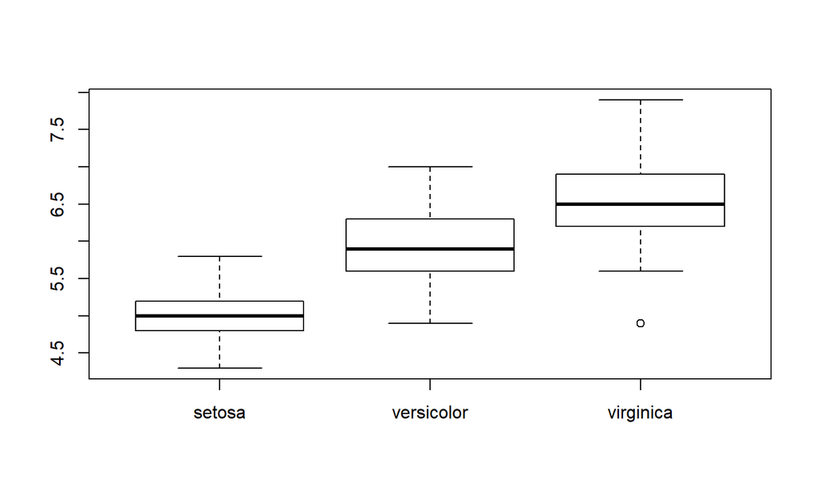

```r
boxplot(Sepal.Length~Species, data=iris)
```

## Explorando multiples variables 4:

- 5 Scatter plot

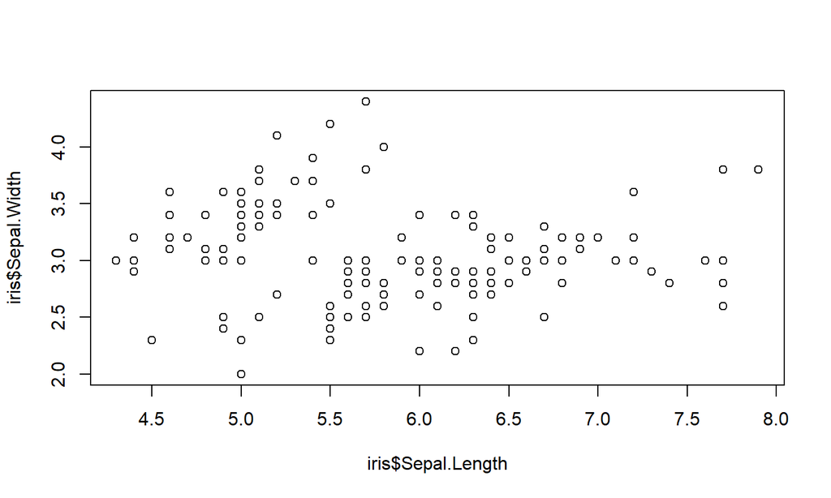

```r
plot(iris$Sepal.Length, iris$Sepal.Width)
```

## Explorando multiples variables 5:

- 6 Pairs plot

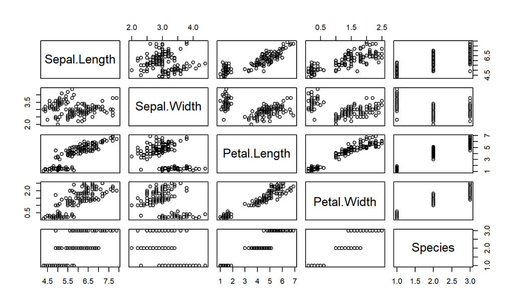

```r
pairs(iris)
```

## Explorando multiples variables 6:

- 7 other complicated plots

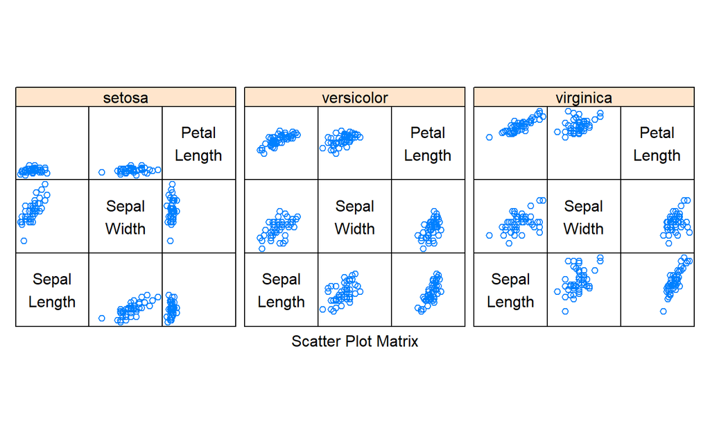

```r
library(lattice)
splom(~iris[1:3] | Species, data = iris, pscales = 0,varnames = c("Sepal\nLength", "Sepal\nWidth", "Petal\nLength"))
```

## Explorando multiples variables 7:

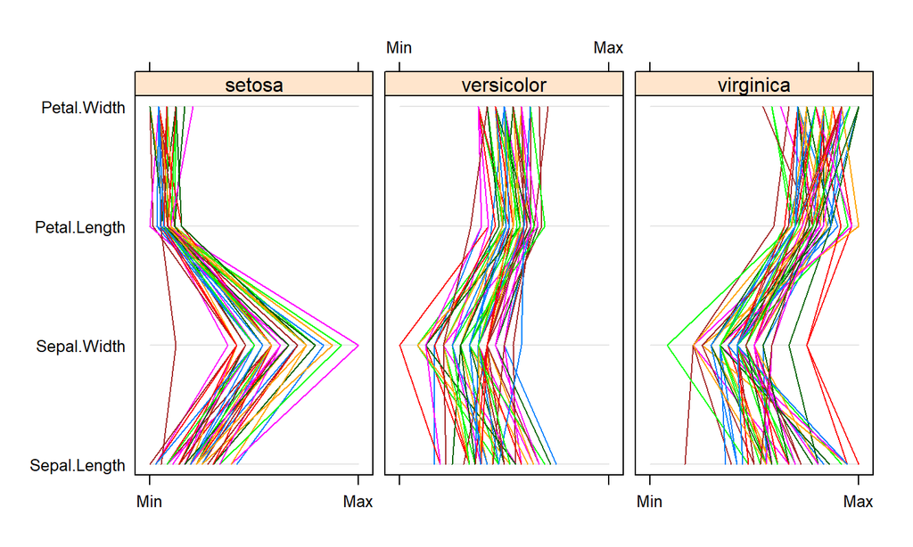

```r
parallel(~iris[, 1:4] | Species, data = iris, layout = c(3, 1))
```

- 3D Scatter plot

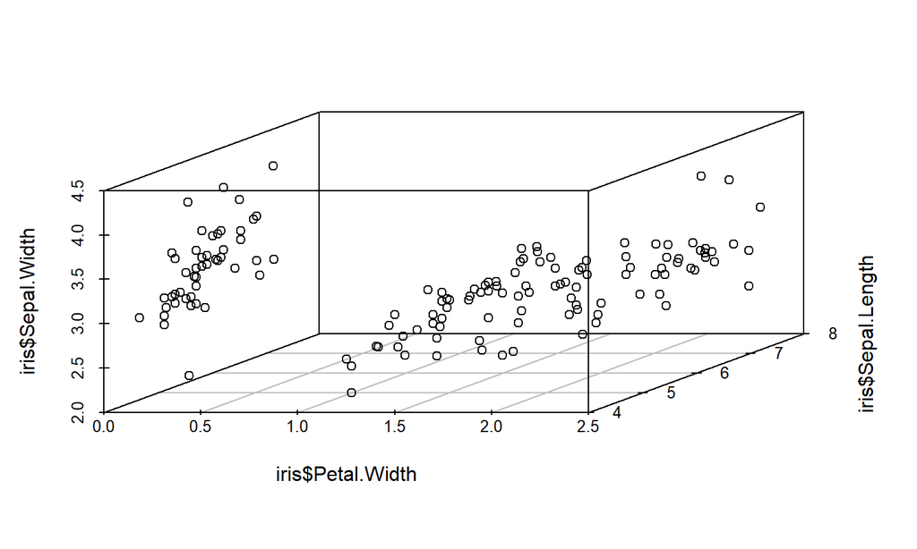

```r
library(scatterplot3d)
scatterplot3d(iris$Petal.Width, iris$Sepal.Length, iris$Sepal.Width)
```

## More Exploration

- Level Plot

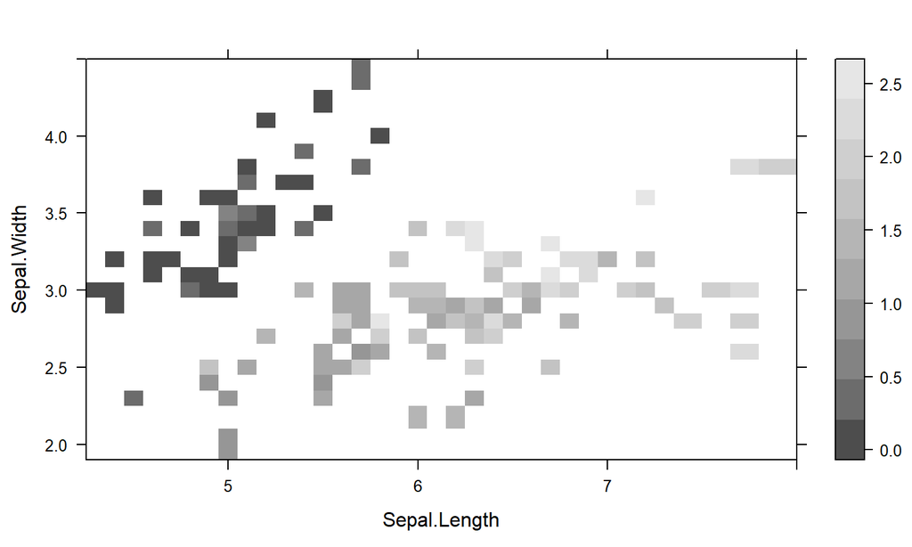

```r
library(lattice)
print(levelplot(Petal.Width~Sepal.Length*Sepal.Width, iris, cuts=9, col.regions=grey.colors(10)))
```

## More Exploration

- Contour

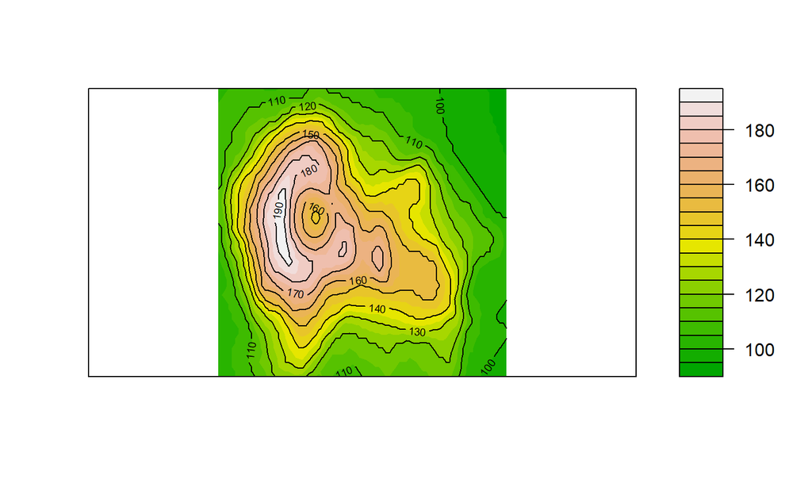

```r
filled.contour(volcano, color = terrain.colors, asp = 1, plot.axes=contour(volcano, add=T) )
```

## More Exploration

- 3D Surface

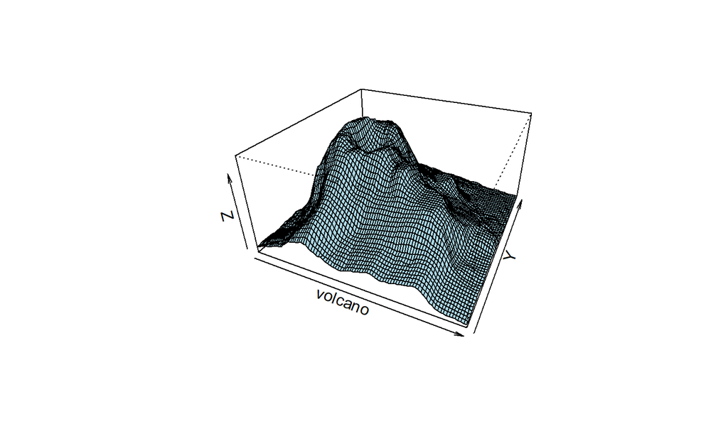

```r
persp(volcano, theta = 25, phi = 30, expand = 0.5, col = "lightblue")
```

## More Exploration

- Interactive 3D Scatter Plot

```r
library(rgl)
plot3d(iris$Petal.Width, iris$Sepal.Length, iris$Sepal.Width)
```

## Writing plots as pdf/ps.

- Save as a .PDF file

```r
pdf("myPlot.pdf")
x <- 1:50
plot(x, log(x))
graphics.off()
```

- Save as a postscript file

```r
postscript("myPlot.ps")
x <- -20:20
plot(x, x^2)
graphics.off()
```

## Writing plots as png/jpeg

- Find temp.. or save as png or jpg

```r
jpeg("plot.jpg")
plot(x, 1/x)
dev.off()
```

## Ejercicios:

Visualizacion es una herramienta muy importante para la generacion de intuicion, pero raramente uno tiene los datos en la forma necesaria. Frecuentemente se necesitara crear nuevas variables o simplemente reordenarlas.

Exploraremos ahora la manipulacion basica utilizando un conjunto de datos sobre los vuelos en Nueva York en 2013.

```r
library(nycflights13)
fligths<-nycflights13::flights
fligths
```

```
## # A tibble: 336,776 x 19
##     year month   day dep_time sched_dep_time dep_delay arr_time
##    <int> <int> <int>    <int>          <int>     <dbl>    <int>
##  1  2013     1     1      517            515         2      830
##  2  2013     1     1      533            529         4      850
##  3  2013     1     1      542            540         2      923
##  4  2013     1     1      544            545        -1     1004
##  5  2013     1     1      554            600        -6      812
##  6  2013     1     1      554            558        -4      740
##  7  2013     1     1      555            600        -5      913
##  8  2013     1     1      557            600        -3      709
##  9  2013     1     1      557            600        -3      838
## 10  2013     1     1      558            600        -2      753
## # ... with 336,766 more rows, and 12 more variables: sched_arr_time <int>,
## #   arr_delay <dbl>, carrier <chr>, flight <int>, tailnum <chr>,
## #   origin <chr>, dest <chr>, air_time <dbl>, distance <dbl>, hour <dbl>,
## #   minute <dbl>, time_hour <dttm>
```

## Practico 1: Entregar un Rmd donde se encuentren todos los vuelos que:

- Que arribaron con un retraso de mas de dos horas.
- Volaron hacia Houston (IAH o HOU)
- Fueron operados por United, American o Delta.
- Salieron en Verano (Julio, Agosto y Septiembre)
- Arrivaron mas de dos horas tarde, pero salieron bien.
- Salieron entre medianoche y las 6 am.